# 140.652s - Lab 16

### HW7 Problem 3

#### (a)

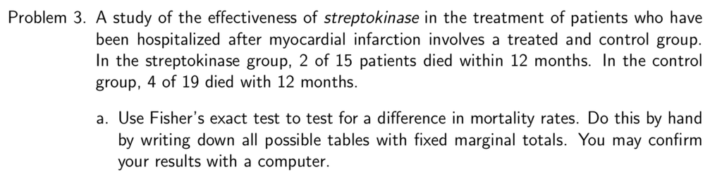

From lecture 21 slide 6, under the null $H_0$,

- $X \sim \operatorname{Binom}\left(n_{1}, p\right)$
- $Y \sim \operatorname{Binom}\left(n_{2}, p\right)$
- $X+Y \sim \operatorname{Binom}\left(n_{1}+n_{2}, p\right)$

Note: If the marginal totals (i.e. all Streptokinase $a+b$, all control $c+d$, all dead $a+c$, and all not dead $b+d$) are known, only a single degree of freedom is left, i.e. the value of $a$ in 2x2 table lets us determine other values in 2x2 table ($b,c,d$).

All possible tables with fixed marginal totals are presented below.

- $P(\text{Table 1}) = p(X = 0 | X + Y = 6)$,
- $P(\text{Table 2}) = p(X = 1 | X + Y = 6)$,
- …
- $P(\text{Table 7}) = p(X = 6 | X + Y = 6)$.

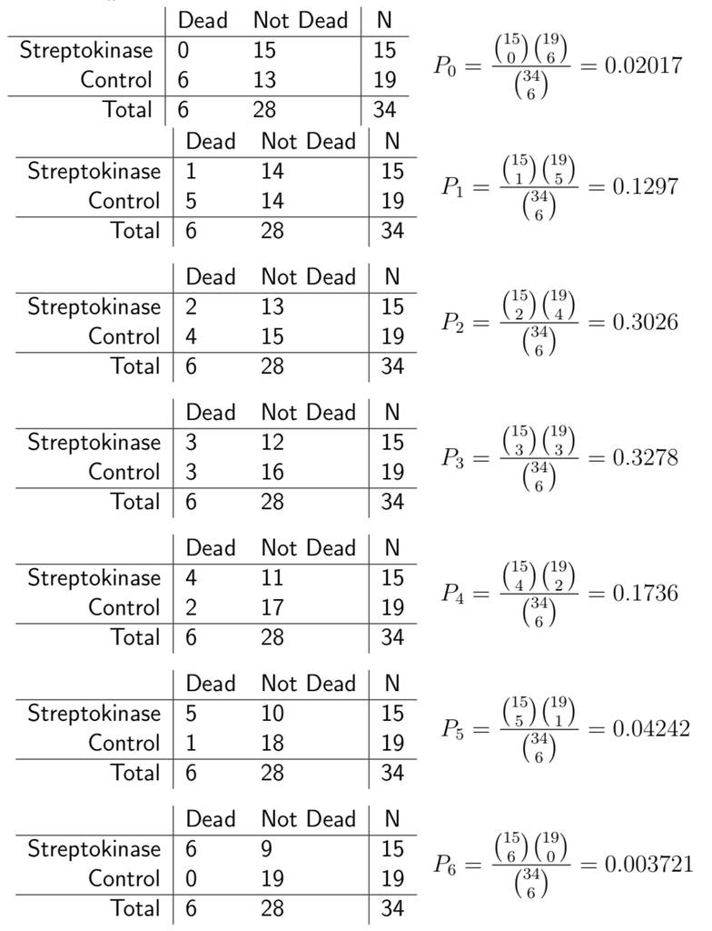

Notes:

- From wiki: Fisher showed that to generate a significance level, we need consider only the cases where the marginal totals are the same as in the observed table, and among those, only the **cases where the arrangement is as extreme as the observed arrangement**.
- From the Lecture 21: p-value requires **tables as extreme or more extreme (under $H_A$) than the one observed**.
- From the `fisher.test()` in R: Two-sided tests are based on the probabilities of the tables, and **take as “more extreme” all tables with probabilities less than or equal to that of the observed table**, the p-value being the sum of such probabilities (based on R’s `fisher.test()` documentation and wiki).

Here:

- We observe $X=2$, i.e. $P_2 = 0.3026$.
- Under the null, $\hat{p}=\frac{6}{34}$, $E(X) = \hat{p} \cdot 15 = 2.65 \approx 3$, i.e. $P_3 = 0.3278$.

This yields:

$$\begin{aligned}
\text{p-value } = \; P _ { 0 } + P _ { 1 } + P _ { 2 } + P _ { 4 } + P _ { 5 } + P _ { 6 } = 0.6722
\end{aligned}$$

We can confirm with `fisher.test()` built-in R function:

```r
# two-dimensional contingency table in matrix form
dat_tbl <- matrix(c(2, 13, 4, 15), byrow = TRUE, ncol = 2)
fisher.test(dat_tbl, alternative = "two.sided") ## two sided test
```

```
##
##  Fisher's Exact Test for Count Data
##
## data:  dat_tbl
## p-value = 0.6722
## alternative hypothesis: true odds ratio is not equal to 1
## 95 percent confidence interval:
##  0.04590206 4.89390008
## sample estimates:
## odds ratio
##   0.586089
```

#### (b)

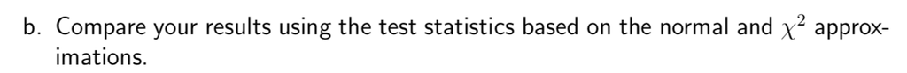

1. **Normal approximation.**

$$\begin{aligned}
\hat { p } _ { t } & = 2 / 15 = 0.1333 \\
\hat { p } _ { c } & = 4 / 19 = 0.2105 \\
\hat { p } & = ( 2 + 4 ) / ( 15 + 19 ) = 0.1765
\end{aligned}$$

and

$$\begin{aligned}
T S & = \frac { \hat { p } _ { c } - \hat { p } _ { t } - 0 } { \sqrt { \hat { p } ( 1 - \hat { p } ) \left( \frac { 1 } { n _ { 1 } } + \frac { 1 } { n _ { 2 } } \right) } } \\
& = \frac { 0.2105 - 0.1333 } { \sqrt { ( 0.1765 ) ( 1 - 0.1765 ) \left( \frac { 1 } { 15 } + \frac { 1 } { 19 } \right) } } \\
& = 0.5863
\end{aligned}$$

```r
# compute p-value in two-sided test corresponding to this test statistics
TS <- 0.5863
2 * pnorm(-TS)
```

```
## [1] 0.5576739
```

2. **$\chi^2$ approximation.**

The test statistic is given by:

$$\begin{aligned}
\chi ^ { 2 } = \sum \frac { ( O - E ) ^ { 2 } } { E }
\end{aligned}$$

Plugging the values from problem formulation, we get:

$$\begin{aligned}
O _ { 11 } & = 2 : \frac { \left( 2 - \left( \frac { 15 } { 34 } \right) \left( \frac { 6 } { 34 } \right) 34 \right) ^ { 2 } } { \frac { 15 \times 6 } { 34 } } = 0.1582 \\
O _ { 12 } & = 13 : \frac { \left( 13 - \left( \frac { 15 } { 34 } \right) \left( \frac { 28 } { 34 } \right) 34 \right) ^ { 2 } } { \frac { 15 \times 28 } { 34 } } = 0.03389 \\
O _ { 21 } & = 4 : \frac { \left( 4 - \left( \frac { 19 } { 34 } \right) \left( \frac { 6 } { 34 } \right) 34 \right) ^ { 2 } } { \frac { 19 \times 6 } { 34 } } = 0.1249 \\
O _ { 22 } & = 15 : \frac { \left( 15 - \left( \frac { 19 } { 34 } \right) \left( \frac { 28 } { 34 } \right) 34 \right) ^ { 2 } } { \frac { 19 \times 28 } { 34 } } = 0.02676
\end{aligned}$$

and hence

$$\begin{aligned}
\chi ^ { 2 } = 0.1582 + 0.03389 + 0.1249 + 0.026776 = 0.3437.
\end{aligned}$$

```r
# compute p-value in two-sided test corresponding to this test statistics
chi2 <- 0.3436926
pchisq(chi2, df = 1, lower.tail = FALSE)
```

```
## [1] 0.5577055
```

Summary of p-value (two-sided test):

- Fisher’s Exact: $0.6722$
- Normal approx: $0.5577$
- $\chi^2$ approx: $0.5577$

Hence:

- The conclusion is the same for all three tests: we fail to reject the null hypothesis that there is no difference in mortality rates between the two groups.
- However, the p-values generated by each method are different. Because the sample size is small, one way to think is that the exact test is the most appropriate/conservative method in this case.

### HW7 Problem 5

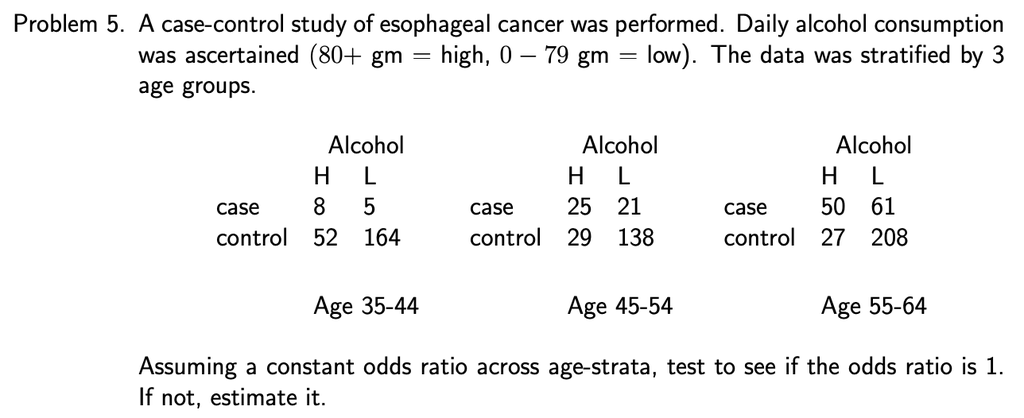

Denote $\theta_k$ - odds ratio in $k$-th age group $k=1,2,3$. The test hypothesis:

$$\begin{aligned}
H_0: \theta_1 & = \theta_2 = \theta_3 = 1 \\
H_a: \theta_1 & = \theta_2 = \theta_3 \neq 1.
\end{aligned}$$

We will use Mantel / Haenszel estimator/test. Reference: Lecture 23, slides 14-19. Some other notes about Mantel / Haenszel estimator/test from [here](https://www.itl.nist.gov/div898/software/dataplot/refman1/auxillar/mantel.htm#:~:text=The%20Mantel%2DHaenszel%20test%20can,table%20has%20large%20marginal%20frequencies.):

The Mantel-Haenszel test can be used to estimate the common odds ratio and to test whether the overall degree of association is significant. It is a consistent estimator in the following two cases:

1. When the number of tables is fixed, and possibly small, but each table has large marginal frequencies.
2. The number of tables is large. The marginal frequencies can be small in the individual tables.

```r
a35 <- matrix(c(8,5,52,164),ncol=2,byrow=TRUE)
a45 <- matrix(c(25,21,29,138),ncol=2,byrow=TRUE)
a55 <- matrix(c(50,61,27,208),ncol=2,byrow=TRUE)
mantelhaen.test(array(c(a35,a45, a55), c(2, 2, 3)),correct=FALSE)
```

```
##
##  Mantel-Haenszel chi-squared test without continuity correction
##
## data:  array(c(a35, a45, a55), c(2, 2, 3))
## Mantel-Haenszel X-squared = 83.725, df = 1, p-value < 2.2e-16
## alternative hypothesis: true common odds ratio is not equal to 1
## 95 percent confidence interval:
##  3.959672 8.904458
## sample estimates:
## common odds ratio
##          5.937907
```

- 95% CI for common odds ratio: $[3.959672, 8.904458]$
- Common odds ratio estimate: $5.937907$

We will now see it agrees with computation by hand. From the Lecture 23 slide 14, the Mantel / Haenszel estimator is given by:

$$\begin{aligned}
\hat { \theta } _ { M H } = \frac { \sum _ { k } \frac { n _ { 11 k } n _ { n 22 k } } { n _ { + + k } } } { \sum _ { k } \frac { n _ { 12 k } n _ { 21 k } } { n _ { + + k } } }.
\end{aligned}$$

Plugging data from the problem formulation, we get:

$$\begin{aligned}
\hat { \theta } _ { M H } = \frac { \frac { 8 \times 164 } { 229 } + \frac { 25 \times 138 } { 213 } + \frac { 50 \times 208 } { 346 } } { \frac { 52 \times 5 } { 229 } + \frac { 29 \times 21 } { 213 } + \frac { 27 \times 61 } { 346 } } = 5.938
\end{aligned}$$

### HW7 Problem 11

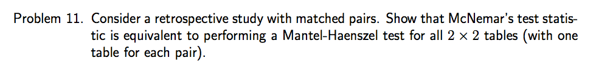

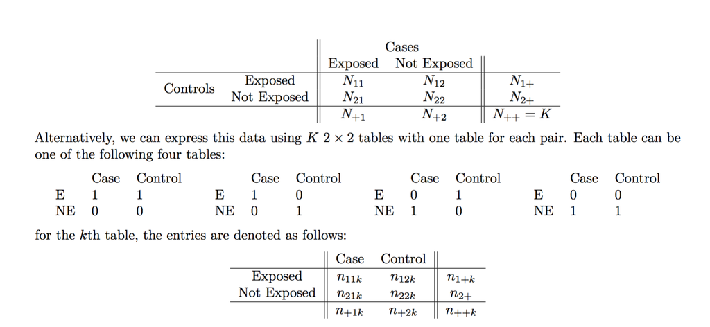

- Suppose we have $K$ matched pairs (i.e. $K$ contingency tables). Thenthe CMH test statistic is $\frac{[\sum_k\{n_{11k} - E(n_{11k})\}]^2}{\sum_k \text{Var}(n_{11k})}$ (Lecture 23, slide 17).
- In a restrospective case-control study, each of the $K$ tables has one case and one control, hence the column totals are 1, i.e. $n_{+1k}=n_{+2k}=1$ and $n_{++k}=2$.

Observe that

$$\begin{eqnarray}
\sum_k\{n_{11k} - E(n_{11k})\} & = & \sum_k \{n_{11k} - n_{1+k}n_{+1k}/n_{++k}\} \nonumber \\
& = & \sum_k (n_{11k}-n_{1+k}/2) \phantom{000}\text{Because column totals are fixed as 1.} \nonumber \\
& = & \sum_k (n_{11k}-n_{12k})/2 \nonumber \\
& = & \left[(N_{11} + N_{21}) - (N_{11} + N_{12}) \right]/2 \nonumber \\
& = & (N_{12}-N_{21})/2 \nonumber
\end{eqnarray}$$

And

$$\begin{eqnarray}
\sum_k \text{Var}(n_{11k}) & = & \sum_k n_{1+k}n_{2+k}n_{+1k}n_{+2k}/n_{++k}^2(n_{++k}-1) \nonumber \\
& = & \sum_k n_{1+k}n_{2+k}/4 \nonumber \\
& = & (N_{12} + N_{21})/4 \nonumber
\end{eqnarray}$$

**$n_{1+k}n_{2+k}=1$ if and only if the case is exposed, the control is unexposed; or the control is exposed, the case is unexposed.** Otherwise $n_{1+k}n_{2+k}=0$.

Putting it all together, we have

$$\begin{eqnarray}
\frac{[\sum_k\{n_{11k} - E(n_{11k})\}]^2}{\sum_k \text{Var}(n_{11k})} & = & \frac{[(N_{12}-N_{21})/2]^2}{(N_{12}+N_{21})/4} \nonumber \\
& = & \frac{(N_{12}-N_{21})^2}{N_{12} + N_{21}} \nonumber
\end{eqnarray}$$

### HW7 Problem 12

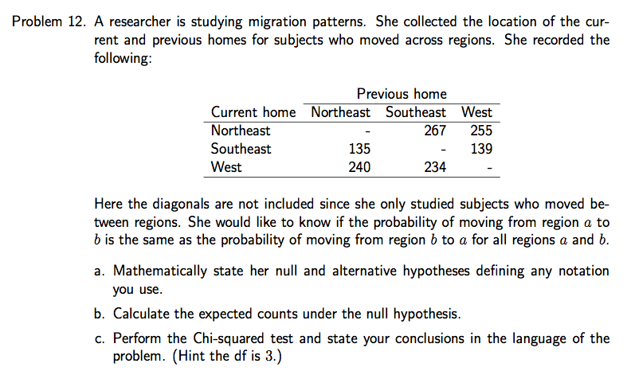

##### a. Mathematically state her null and alternative hypotheses defining any notation you use.

We assume individuals in this population were randomly sampled. Here we’re being given a null hypothesis of **symmetry**. More precisely,

$$\begin{align}
H_0:& \pi_{ij} = \pi_{ji}, \phantom{000} i,j \in \{\text{Northeast, Southeast, West}\} \nonumber \\
H_a:& \text{At least one $\pi_{ij} \neq \pi_{ji}$} \nonumber
\end{align}$$

##### b. Calculate the expected counts under the null hypothesis.

- **We do not have the diagonal numbers in the table since they are not relatvant in testing symmetry**.
- Under the null hypothesis, $\pi_{12}=\pi_{21}$, hence the expected count is the average of cell (1,2) and (2,2): $E[n_{12}]=E[n_{21}]=(n_{12} + n_{21})/2$.
- The expected diagonal counts under the null is themselves, i.e. $E[n_{11}]=n_{11}$. The corresponding term in the $\chi^2$ statistic is 0.

```r
# E[n_{12}] = E[n_{21}]
E1 <- (135 + 267)/2
# E[n_{13}] = E[n_{31}]
E2 <- (255 + 240)/2
# E[n_{23}] = E[n_{32}]
E3 <- (139 + 234)/2
```

##### c. Perform the Chi-squared test and state your conclusions in the language of the problem. (Hint the df is $3$.)

$$\chi^2=\sum \frac{(observed-expected)^2}{expected}$$

This statistic has $\chi^2$ distribution with 3 degrees of freedom.

- The “null” model restricts 3 parameters, hence reduces 3 degrees of freedom compared to the “saturated” model.
- The df of the $\chi^2$ statistic is equal to the df difference between the null and saturated model.
- Null model: symmetry is satisfied ($\pi_{12}=\pi_{21}, \pi_{13}=\pi_{31}, \pi_{23}=\pi_{32}$). Saturated model: no restrictions.

```r
chi2 = (135-E1)^2/E1 + (267-E1)^2/E1 + (255-E2)^2/E2 + (240-E2)^2/E2 + (139-E3)^2/E3 + (234-E3)^2/E3
chi2
```

```
## [1] 67.99354
```

```r
# p-value
pchisq(chi2, df = 3, lower.tail = FALSE)
```

```
## [1] 1.147668e-14
```

We obtain a p-value that is $<0.001$ leading us to reject the null hypothesis and the conclude that the data supports the hypothesis that the probability of moving from each of these regions is not symmetric across the three regions.